# Rocky Intertidal Biogeochemistry — Exploratory Analysis

## Heatmap

Diel variability heatmap; however, if benthos is not significant, it doesn’t make sense to compare to OO. Interaction was not significant either, so it doesn’t make sense to look at seasonal variabilty in comparison to the OO either.

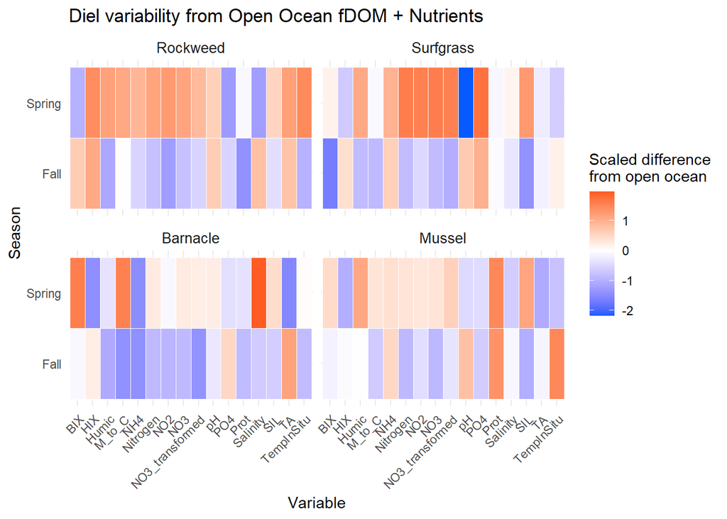

```r
# take means of all variables
fdom_heatmap_data <- diel_data %>%
  group_by(Benthos, Season, variable) %>%
  summarise(delta_diel_mean = mean(delta_diel, na.rm = TRUE),
            .groups = "drop")

# get open ocean means for comparison
open_ocean_ref <- fdom_heatmap_data %>%
  filter(Benthos == "Open Ocean") %>%
  select(-Benthos) %>%
  rename(OpenOcean_Value = delta_diel_mean)

# join both to calculate ΔOO
fdom_diff <- fdom_heatmap_data %>%
  filter(Benthos != "Open Ocean") %>%
  left_join(open_ocean_ref,
            by = c("Season","variable")) %>%
  mutate(Diff_from_OO = delta_diel_mean - OpenOcean_Value)

# scale the differences so we can plot it
fdom_diff <- fdom_diff %>%
  group_by(variable) %>%
  mutate(Diff_Scaled = as.numeric(scale(Diff_from_OO))) %>%
  ungroup()

# heat map colored by difference from open ocean
fdom_diff %>%
  ggplot(aes(x = variable,
             y = Season,
             fill = Diff_Scaled)) +
  geom_tile(color = "white") +
  scale_fill_gradient2(
    low = "#075AFF", mid = "white", high = "#FF4500",
    midpoint = 0, name = "Scaled difference\nfrom open ocean"
  ) +
  labs(
    title = "Diel variability from Open Ocean fDOM + Nutrients",
    x = "Variable",
    y = "Season"
  ) +
  theme_minimal() +
  facet_wrap(~Benthos) +
  theme(
    axis.text.x = element_text(angle = 45, hjust = 1),
    strip.text = element_text(size = 10)
  )
```

## Seasonal plots Here’s the seasonal variability within benthos in diel variation with significance

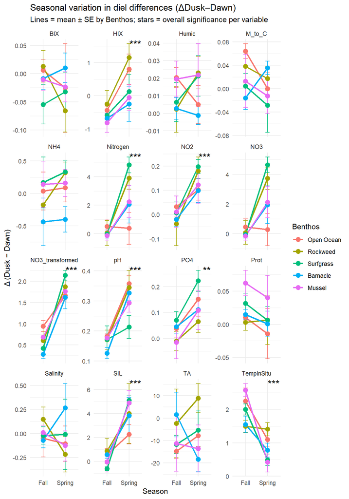

```r
anovas <- anovas %>%
  mutate(sig = case_when(
          `Pr(>F)` < 0.001 ~ "***",
          `Pr(>F)` < 0.01  ~ "**",
          `Pr(>F)` < 0.05  ~ "*"
        ))

# get one sig label per variable (you can pick any rule you want)
sig_labels <- anovas %>%
  group_by(variable) %>%
  summarize(sig = paste(unique(sig[sig != ""]), collapse = ""), .groups = "drop") %>%
  mutate(x = Inf, y = Inf)  # position top-right corner in each facet

ggplot(diel_data, aes(x = Season, y = delta_diel, color = Benthos, group = Benthos)) +
  stat_summary(fun = mean, geom = "line", linewidth = 1) +
  stat_summary(fun.data = mean_se, geom = "errorbar", width = 0.2) +
  stat_summary(fun = mean, geom = "point", size = 3) +
  facet_wrap(~ variable, scales = "free_y") +
  geom_text(
    data = sig_labels,
    aes(x = x, y = y, label = sig),
    color = "black", size = 5, hjust = 1.1, vjust = 1.1, inherit.aes = FALSE
  ) +
  theme_minimal() +
  labs(
    title = "Seasonal variation in diel differences (ΔDusk–Dawn)",
    subtitle = "Lines = mean ± SE by Benthos; stars = overall significance per variable",
    y = "Δ (Dusk − Dawn)"
  )
```

# Dawn vs Dusk

This could be due to lost samples using diel variability, let’s look at Day_Night results

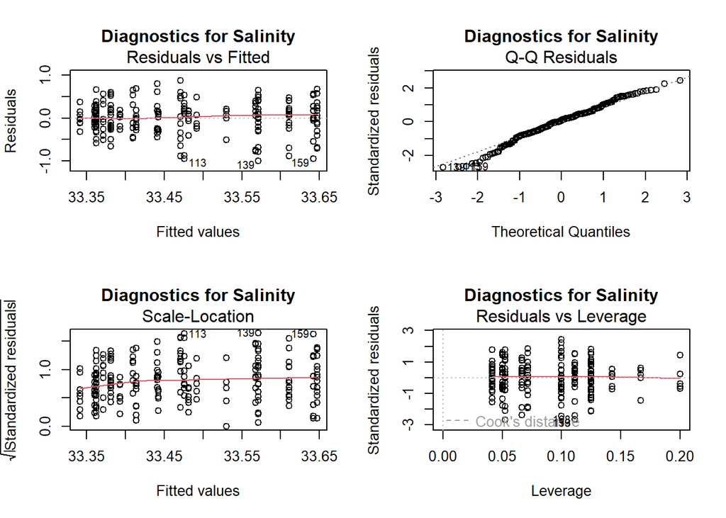

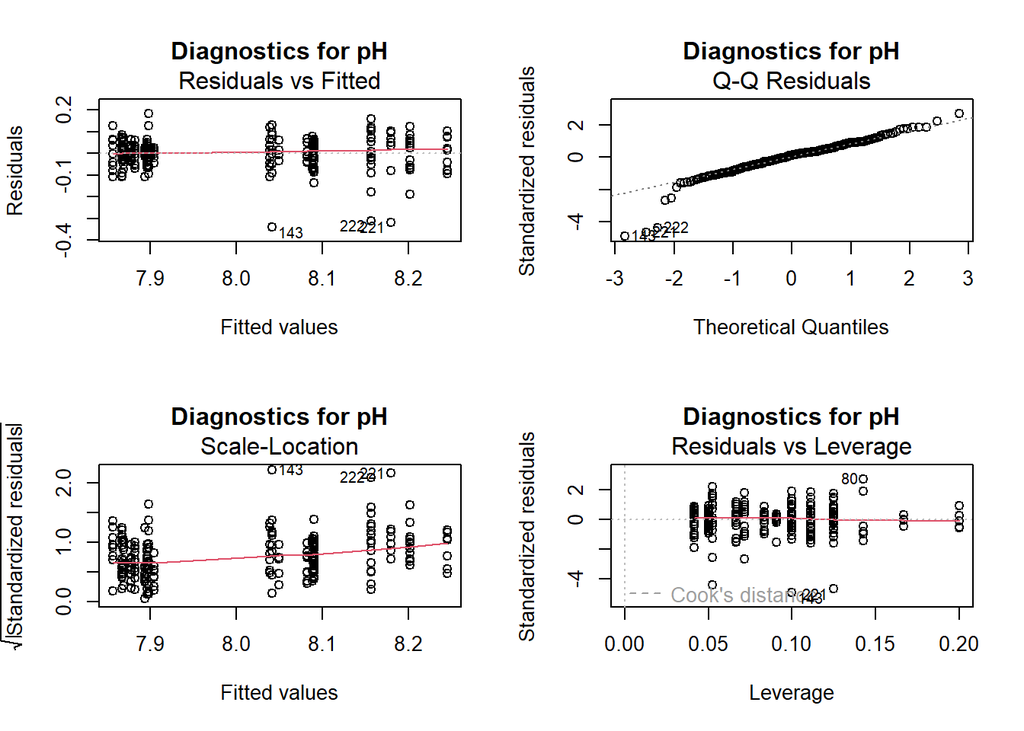

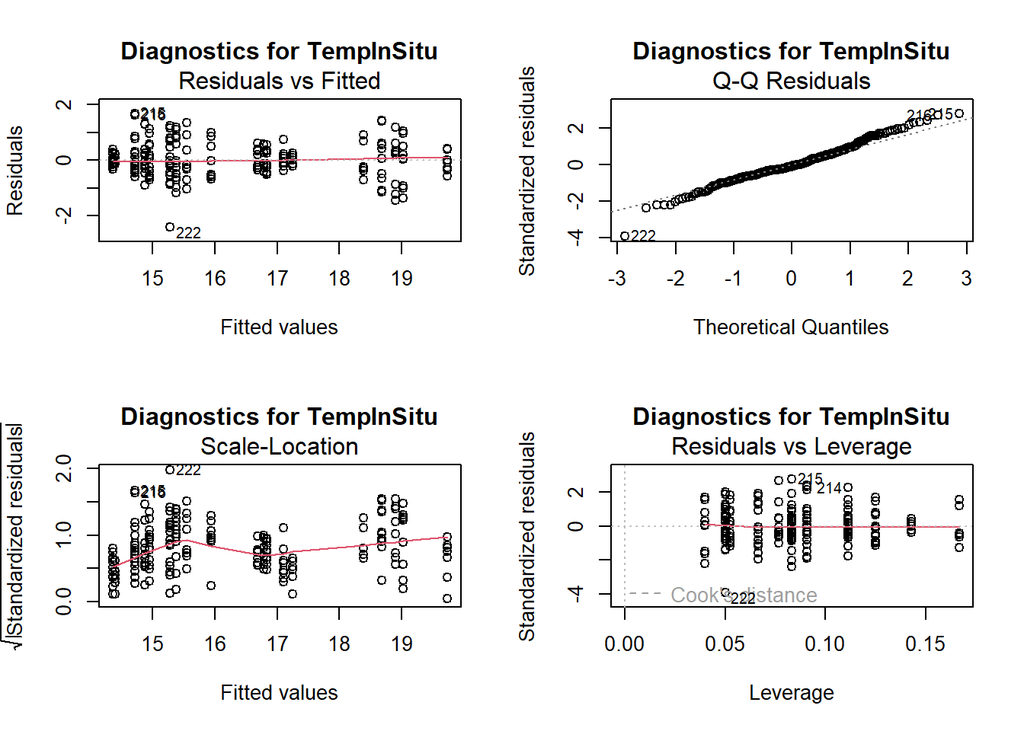

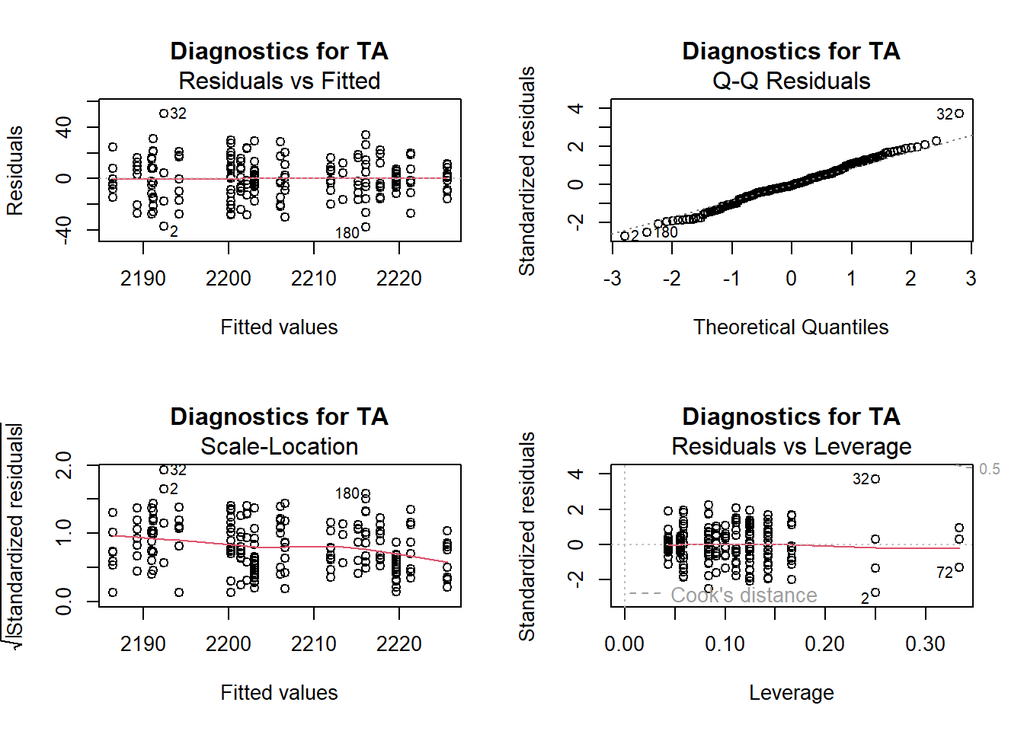

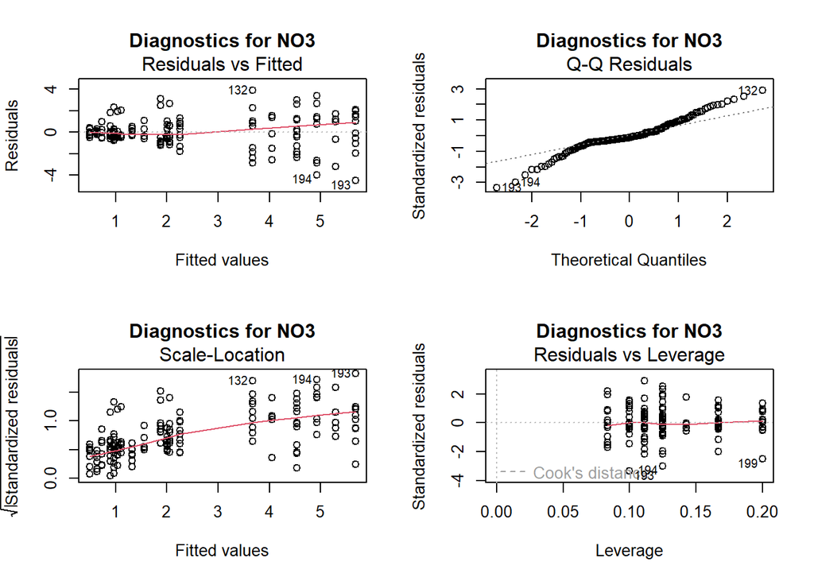

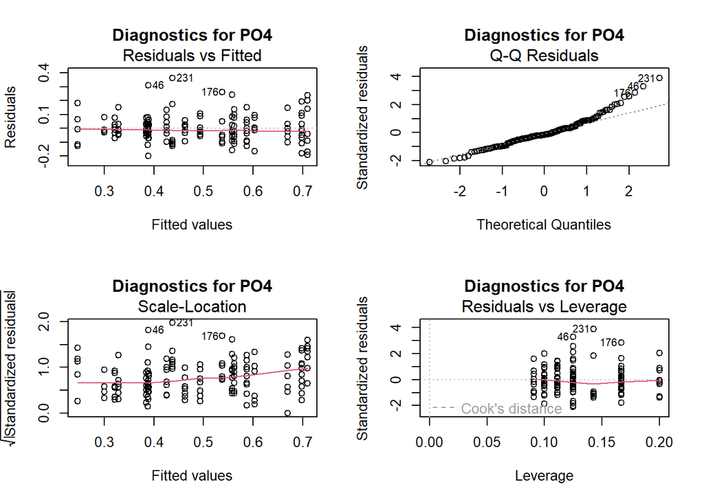

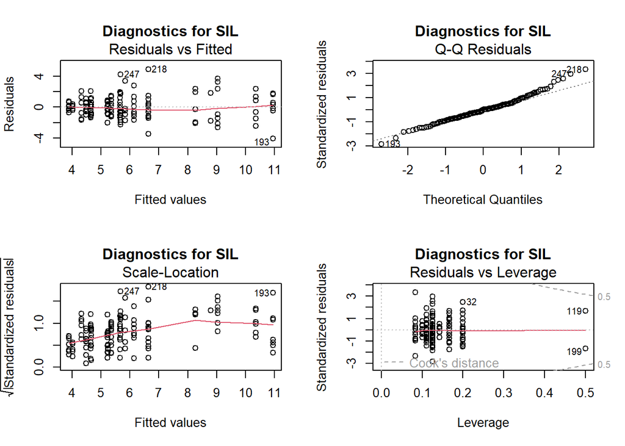

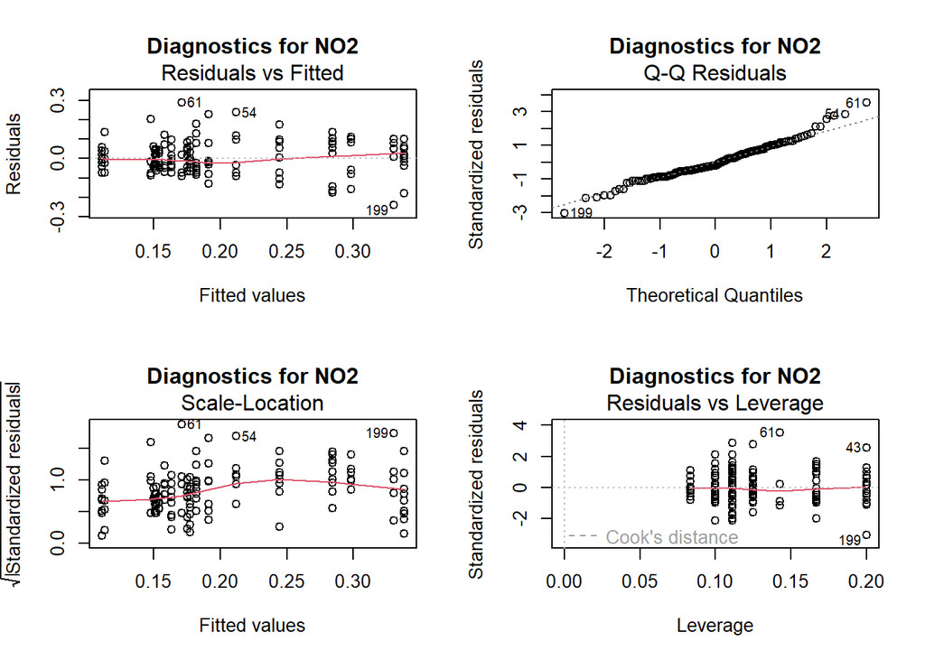

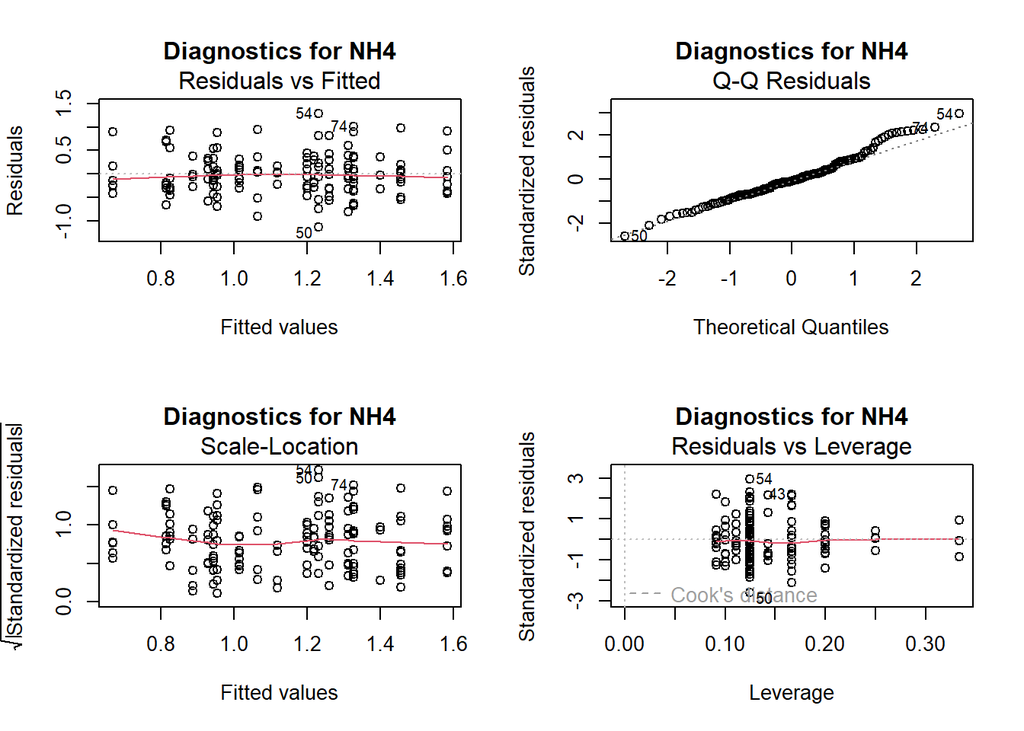

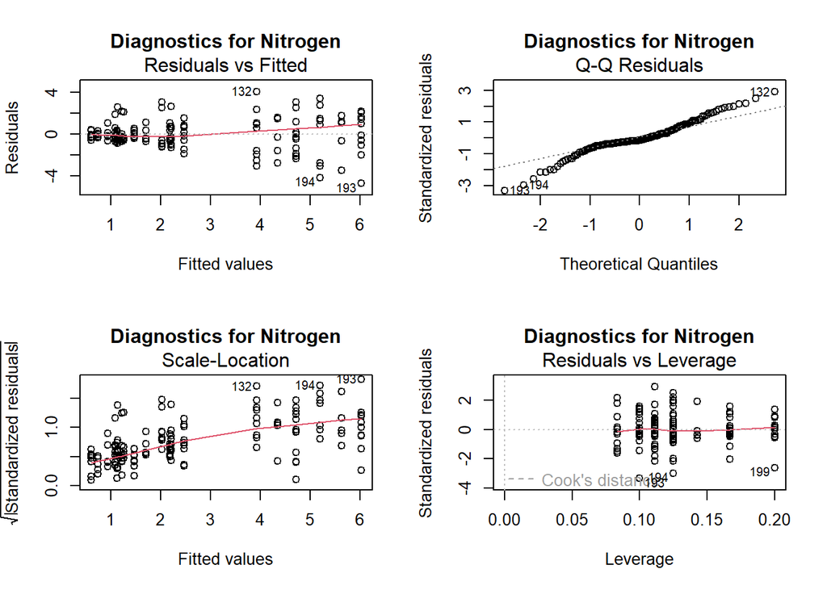

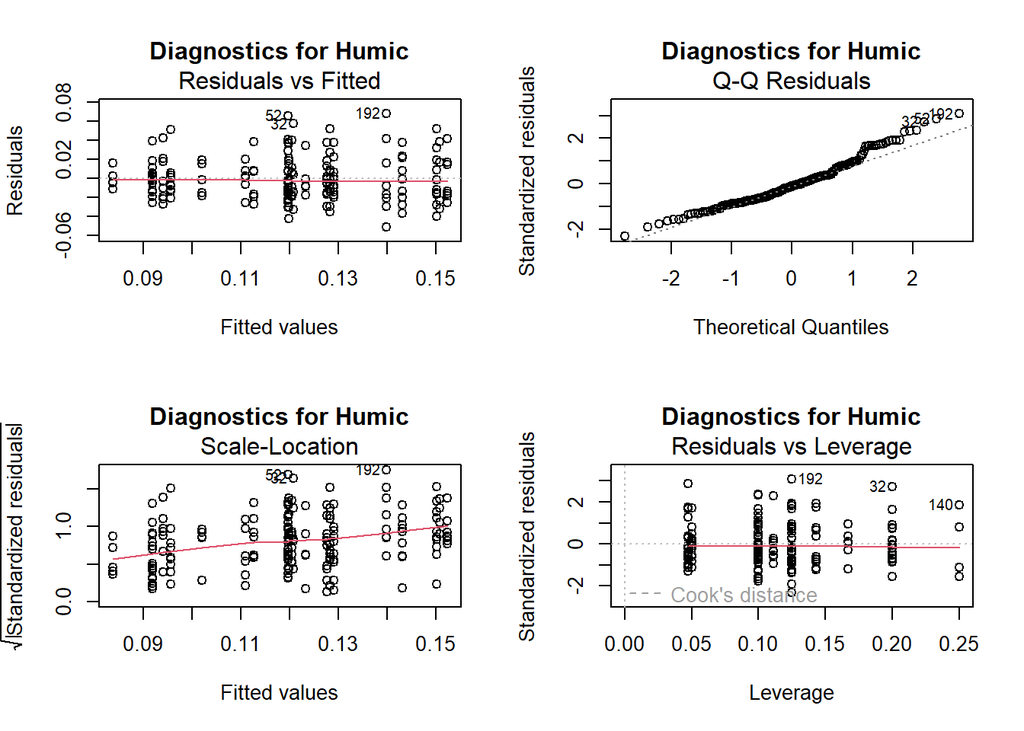

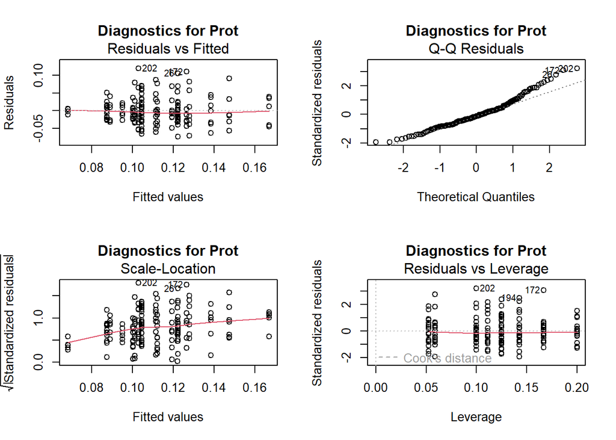

[3 more figures not shown]

```
## # A tibble: 0 × 0
```

```r
# create long format df
testing_df <- data_clean %>%
  pivot_longer(cols = all_of(all_numeric_vars),
               names_to = "variable", values_to = "Value")

nutrient_vars <- c("NO3", "PO4", "SIL", "NO2", "NH4", "Nitrogen")
all_numeric_vars_normal <- c(water_chem_vars, nutrient_vars, fdom_vars)

# running lm and creating diagnostic plots
map_dfr(all_numeric_vars, function(v){
  df_sub <- testing_df %>%
    filter(variable == v) # filter by variable
    options(contrasts = c("contr.sum", "contr.poly"))
    fit <- lm(Value ~ Day_Night * Benthos * Season, data = df_sub)
  par(mfrow = c(2,2)) # create 2x2 for plots
  plot(fit, main = paste("Diagnostics for", v)) # check assumptions using qq and residuals plots
})
```

```r
# okay NO3, PO4, Humic, Prot, HIX looks like they need to be transformed

transform_var <- c("NO3", "PO4", "Humic", "Prot", "HIX")
transformed_var <- map_dfr(transform_var, function(v){
  testing_df %>%
    filter(variable == v) %>% # filter by variable
    mutate(Value = sqrt(Value),
           variable = paste0(v,"_transformed"))
})

testing_df_norm <- bind_rows(testing_df, transformed_var)

diel_data <- bind_rows(diel_data, diel_data_NO3)

nutrient_vars <- c("NO3_transformed", "PO4_transformed", "SIL", "NO2", "NH4", "Nitrogen")
fdom_vars <- c("Humic_transformed","Prot_transformed", "BIX", "HIX_transformed", "M_to_C")
all_numeric_vars_normal <- c(water_chem_vars, nutrient_vars, fdom_vars)

# let's see all ANOVA results together
anovas_full <- map_dfr(all_numeric_vars_normal, function(v){
  df_sub <- testing_df_norm %>%
    filter(variable == v) # filter by variable
    options(contrasts = c("contr.sum", "contr.poly"))
    fit <- lm(Value ~ Day_Night * Benthos * Season, data = df_sub)
    Anova(fit, type = "III") %>%
    as.data.frame() %>%
    rownames_to_column("term") %>%
    filter(term != "(Intercept)") %>%
    filter(`Pr(>F)` < 0.05) %>% # see what's significant
    mutate(variable = v)
})

anovas_full
```

```
##                        term       Sum Sq Df     F value       Pr(>F)
## 1                 Day_Night 2.599064e+00  1  487.451602 9.434985e-56
## 2                   Benthos 7.190698e-02  4    3.371518 1.070830e-02
## 3                    Season 6.563424e-02  1   12.309629 5.554222e-04
## 4         Day_Night:Benthos 5.461228e-02  4    2.560618 3.975278e-02
## 5          Day_Night:Season 1.623987e-01  1   30.457696 1.039131e-07
## 6            Benthos:Season 8.394817e-02  4    3.936096 4.237200e-03
## 7  Day_Night:Benthos:Season 5.922828e-02  4    2.777049 2.810384e-02
## 8                 Day_Night 1.048544e+02  1  264.463808 6.040089e-40
## 9                   Benthos 7.448054e+00  4    4.696370 1.165326e-03
## 10                   Season 4.598255e+02  1 1159.771984 3.574828e-91
## 11         Day_Night:Season 2.055130e+01  1   51.834478 8.769567e-12
## 12           Benthos:Season 5.722078e+00  4    3.608056 7.127218e-03
## 13 Day_Night:Benthos:Season 6.190606e+00  4    3.903487 4.368286e-03
## 14                Day_Night 2.734707e+03  1   11.059760 1.077256e-03
```

[output cut: 93 more lines]

Summary Table

[output not shown]

Let’s look at differences across benthos in their dawn/dusk values over the two seasons

Heatmap colored in comparison to OO

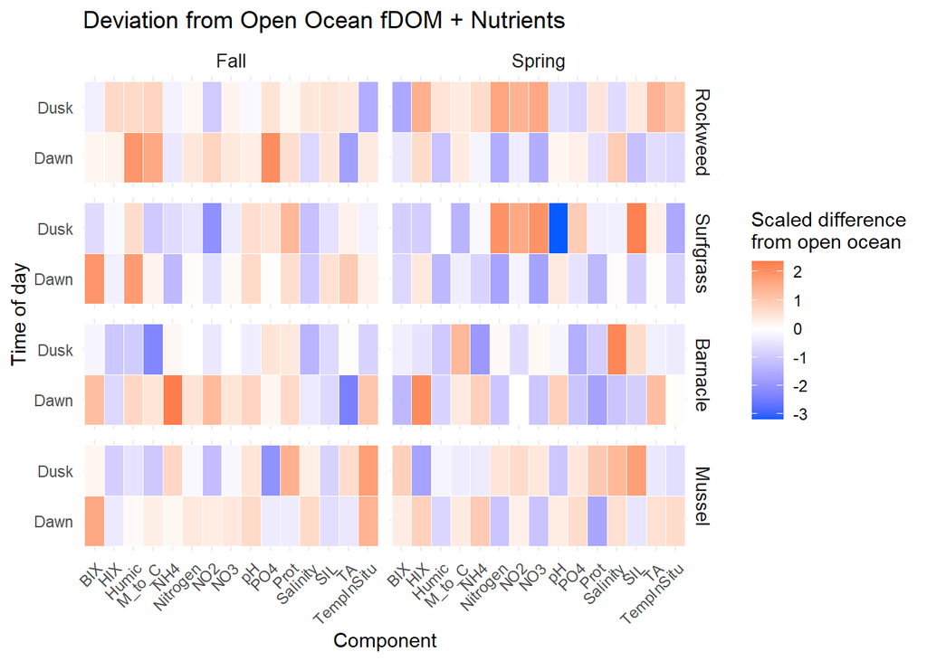

```r
# take means of all variables
heatmap_data <- data_clean %>%
  group_by(Benthos, Day_Night, Season) %>%
  summarise(across(all_of(all_numeric_vars), ~ mean(.x, na.rm = TRUE)),
            .groups = "drop") %>%
  pivot_longer(cols = all_of(all_numeric_vars),
               names_to = "variable",
               values_to = "Mean_Value")

# get open ocean means for comparison
open_ocean_ref <- heatmap_data %>%
  filter(Benthos == "Open Ocean") %>%
  select(-Benthos) %>%
  rename(OpenOcean_Value = Mean_Value)

# join both to calculate ΔOO
fdom_diff <- heatmap_data %>%
  filter(Benthos != "Open Ocean") %>%
  left_join(open_ocean_ref,
            by = c("Day_Night","Season","variable")) %>%
  mutate(Diff_from_OO = Mean_Value - OpenOcean_Value)

# scale the differences so we can plot it
fdom_diff <- fdom_diff %>%
  group_by(variable) %>%
  mutate(Diff_Scaled = as.numeric(scale(Diff_from_OO))) %>%
  ungroup()

# heat map colored by difference from open ocean
fdom_diff %>%
  ggplot(aes(x = variable,
             y = Day_Night,
             fill = Diff_Scaled)) +
  geom_tile(color = "white") +
  scale_fill_gradient2(
    low = "#075AFF", mid = "white", high = "#FF4500",
    midpoint = 0, name = "Scaled difference\nfrom open ocean"
  ) +
  labs(
    title = "Deviation from Open Ocean fDOM + Nutrients",
    x = "Component",
    y = "Time of day"
  ) +
  theme_minimal() +
  facet_grid(Benthos ~ Season) +
  theme(
    axis.text.x = element_text(angle = 45, hjust = 1),
    strip.text = element_text(size = 10)
  )
```

Adding significance levels from ANOVA

```r
# filter out NAs
testing_df_norm <- testing_df_norm %>%
  filter(!is.na(Value))%>%
  mutate(Season = as.factor(Season))

compute_sig_to_ctrl <- function(testing_df_norm, vars = all_numeric_vars_normal) {

  options(contrasts = c("contr.sum", "contr.poly")) # set contrasts for type III ANOVA

  res_tbl <- map(vars, function(v) {
    df <- testing_df_norm %>%
      filter(variable == v)

    fit <- lm(Value ~ Benthos * Day_Night * Season, data = df) # create lm
    model <- Anova(fit, type = "III")
    emm <- emmeans(fit, ~ Benthos | Day_Night * Season) # emmeans for tukey's hsd
    vs_ctrl <- contrast(emm, method = "trt.vs.ctrl", ref = control_label, adjust = "mvt")
    td  <- as.data.frame(vs_ctrl)

    comp_tbl <- td %>%
      separate(contrast, c("left","right"), sep = " - ", remove = FALSE) %>%
      mutate(
        Benthos  = if_else(right == control_label, left, right),
        variable = v,
        sig = case_when(
          is.na(p.value)  ~ NA_character_,
          p.value < 0.001 ~ "***",
          p.value < 0.01  ~ "**",
          p.value < 0.05  ~ "*",
          TRUE            ~ ""
        )
      )
    ctrl_tbl <- crossing(
      variable = v,
      Season   = unique(td$Season),
      Day_Night= unique(td$Day_Night),
      Benthos  = control_label
    ) %>%
      mutate(
        estimate = NA_real_, SE = NA_real_, df = NA_real_, t.ratio = NA_real_,
        p.value  = NA_real_, sig = ""
      )

    bind_rows(comp_tbl, ctrl_tbl) %>%
      distinct(variable, Season, Day_Night, Benthos, .keep_all = TRUE)
  }) %>% compact() %>% list_rbind()

  res_tbl
}

sig_to_ctrl <- compute_sig_to_ctrl(testing_df_norm) %>%
  mutate(variable = sub("_transformed$", "", variable)) # convert name back for join


# get n so we can add to the plot
n_table <- testing_df_norm %>%
  mutate(variable = sub("_transformed$", "", variable)) %>%
  group_by(Season, Benthos, variable, Day_Night) %>%
  summarise(n = sum(!is.na(Value)), .groups = "drop")

# join all data for plotting
plot_df <- fdom_diff %>%
  left_join(sig_to_ctrl, by = c("Season","Day_Night","Benthos","variable")) %>%
  left_join(n_table,   by = c("Season","Day_Night","Benthos","variable"))
```

## Heatmap in comparison to OO with significance

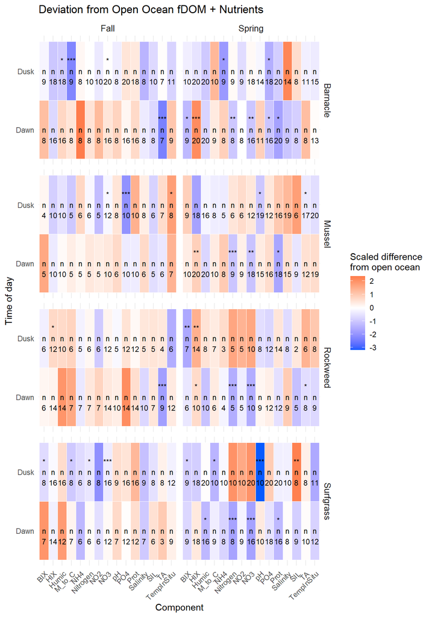

```r
plot_df %>%
  ggplot(aes(x = variable,
             y = Day_Night,
             fill = Diff_Scaled)) +
  geom_tile(color = "white") +
  scale_fill_gradient2(
    low = "#075AFF", mid = "white", high = "#FF4500",
    midpoint = 0, name = "Scaled difference\nfrom open ocean"
  ) +
  labs(
    title = "Deviation from Open Ocean fDOM + Nutrients",
    x = "Component",
    y = "Time of day"
  ) +
  geom_text(aes(label = ifelse(is.na(sig),"",paste0(sig,"\nn\n",n))), color = "black", size = 3) +
  theme_minimal() +
  facet_grid(Benthos ~ Season) +
  theme(
    axis.text.x = element_text(angle = 45, hjust = 1),
    strip.text = element_text(size = 10)
  )
```